# Using SparkR and sparklyr with 2013 NYCTaxi Data: Data manipulations, modeling, and evaluation

### 2.2.1 You can read in raw files in csv.

```r
###########################################
# TRIP FILE (CSV format)
###########################################
tripPath <- file.path(fullDataDir, "trip_data_12.csv")
tripDF <- read.df(tripPath, source = "com.databricks.spark.csv",
                  header = "true", inferSchema = "true")
head(tripDF, 3)
```

```
##                          medallion                     hack_license
## 1 D7D598CD99978BD012A87A76A7C891B7 82F90D5EFE52FDFD2FDEC3EAD6D5771D
## 2 5455D5FF2BD94D10B304A15D4B7F2735 177B80B867CEC990DA166BA1D0FCAF82
## 3 93D6821F86A12B537C5EADBDFB432CA7 28B0AA10202F83FEB0F4E69340CA8F86
##   vendor_id rate_code store_and_fwd_flag     pickup_datetime
## 1       VTS         1                 NA 2013-12-01 00:13:00
## 2       VTS         1                 NA 2013-12-01 00:40:00
## 3       VTS         1                 NA 2013-12-01 02:21:00
##      dropoff_datetime passenger_count trip_time_in_secs trip_distance
## 1 2013-12-01 00:31:00               1              1080          3.90
## 2 2013-12-01 00:48:00               6               480          3.20
## 3 2013-12-01 02:30:00               5               540          3.28
##   pickup_longitude pickup_latitude dropoff_longitude dropoff_latitude
## 1        -73.97934        40.77665         -73.98186         40.73428
## 2        -73.93967        40.72615         -73.98558         40.71807
## 3        -73.95875        40.76808         -73.95875         40.76808
```

```r
printSchema(tripDF)
```

```
## root
##  |-- medallion: string (nullable = true)
##  |-- hack_license: string (nullable = true)
##  |-- vendor_id: string (nullable = true)
##  |-- rate_code: integer (nullable = true)
##  |-- store_and_fwd_flag: string (nullable = true)
##  |-- pickup_datetime: timestamp (nullable = true)
##  |-- dropoff_datetime: timestamp (nullable = true)
##  |-- passenger_count: integer (nullable = true)
##  |-- trip_time_in_secs: integer (nullable = true)
##  |-- trip_distance: double (nullable = true)
##  |-- pickup_longitude: double (nullable = true)
##  |-- pickup_latitude: double (nullable = true)
##  |-- dropoff_longitude: double (nullable = true)
##  |-- dropoff_latitude: double (nullable = true)
```

```r
###########################################
# FARE FILE (parquet format)
###########################################
farePath <- file.path(fullDataDir, "trip_fare_12.csv")
fareDF <- read.df(farePath, source = "com.databricks.spark.csv",
                  header = "true", inferSchema = "true")
head(fareDF, 3)
```

```
##                          medallion                     hack_license
## 1 D7D598CD99978BD012A87A76A7C891B7 82F90D5EFE52FDFD2FDEC3EAD6D5771D
## 2 5455D5FF2BD94D10B304A15D4B7F2735 177B80B867CEC990DA166BA1D0FCAF82
## 3 93D6821F86A12B537C5EADBDFB432CA7 28B0AA10202F83FEB0F4E69340CA8F86
##   vendor_id     pickup_datetime payment_type fare_amount surcharge mta_tax
## 1       VTS 2013-12-01 00:13:00          CRD        15.5       0.5     0.5
## 2       VTS 2013-12-01 00:40:00          CSH        11.5       0.5     0.5
## 3       VTS 2013-12-01 02:21:00          CRD        11.0       0.5     0.5
##   tip_amount tolls_amount total_amount
## 1        3.0            0         19.5
## 2        0.0            0         12.5
## 3        2.3            0         14.3
```

```r
printSchema(fareDF)
```

```
## root
##  |-- medallion: string (nullable = true)
##  |-- hack_license: string (nullable = true)
##  |-- vendor_id: string (nullable = true)
##  |-- pickup_datetime: timestamp (nullable = true)
##  |-- payment_type: string (nullable = true)
##  |-- fare_amount: double (nullable = true)
##  |-- surcharge: double (nullable = true)
##  |-- mta_tax: double (nullable = true)
##  |-- tip_amount: double (nullable = true)
##  |-- tolls_amount: double (nullable = true)
##  |-- total_amount: double (nullable = true)
```

### 2.2.2 Register tables and join using SQL.

You can register dataframes as tables in SQLContext and join using multiple columns. The following SQL also filters the data for some outliers.

```r
###########################################
# 1. REGISTER TABLES AND JOIN ON MULTIPLE COLUMNS, FILTER DATA
# 2. REGISTER JIONED TABLE
###########################################
createOrReplaceTempView(tripDF, "trip")
createOrReplaceTempView(fareDF, "fare")

trip_fareDF <-  SparkR::sql("SELECT
  hour(f.pickup_datetime) as pickup_hour, f.vendor_id, f.fare_amount,
  f.surcharge, f.tolls_amount, f.tip_amount, f.payment_type, t.rate_code,
  t.passenger_count, t.trip_distance, t.trip_time_in_secs
  FROM trip t, fare f
  WHERE t.medallion = f.medallion AND t.hack_license = f.hack_license
  AND t.pickup_datetime = f.pickup_datetime
  AND t.passenger_count > 0 and t.passenger_count < 8
  AND f.tip_amount >= 0 AND f.tip_amount <= 15
  AND f.fare_amount >= 1 AND f.fare_amount <= 150
  AND f.tip_amount < f.fare_amount AND t.trip_distance > 0
  AND t.trip_distance <= 40 AND t.trip_time_in_secs >= 30
  AND t.trip_time_in_secs <= 7200 AND t.rate_code <= 5
  AND f.payment_type in ('CSH','CRD')")
createOrReplaceTempView(trip_fareDF, "trip_fare")

###########################################
# SHOW REGISTERED TABLES
###########################################
head(SparkR::sql("show tables"))
```

```
##   tableName isTemporary
## 1      fare        TRUE
## 2      trip        TRUE
## 3 trip_fare        TRUE
```

### 2.2.3 Feature engineering using SQL

You can create new features using sQL statements. For example, you can use case statements to generate categorical features from coneunuous (numerical) ones.

```r
###########################################
# CREATE FEATURES IN SQL USING CASE STATEMENTS
###########################################
trip_fare_feat <- SparkR::sql("SELECT
    payment_type, pickup_hour, fare_amount, tip_amount,
    passenger_count, trip_distance, trip_time_in_secs,
  CASE
    WHEN (pickup_hour <= 6 OR pickup_hour >= 20) THEN 'Night'
    WHEN (pickup_hour >= 7 AND pickup_hour <= 10) THEN 'AMRush'
    WHEN (pickup_hour >= 11 AND pickup_hour <= 15) THEN 'Afternoon'
    WHEN (pickup_hour >= 16 AND pickup_hour <= 19) THEN 'PMRush'
    END as TrafficTimeBins,
  CASE
    WHEN (tip_amount > 0) THEN 1
    WHEN (tip_amount <= 0) THEN 0
    END as tipped
  FROM trip_fare")

SparkR::persist(trip_fare_feat, "MEMORY_ONLY")
```

```
## SparkDataFrame[payment_type:string, pickup_hour:int, fare_amount:double, tip_amount:double, passenger_count:int, trip_distance:double, trip_time_in_secs:int, TrafficTimeBins:string, tipped:int]
```

```r
SparkR::count(trip_fare_feat)
```

```
## [1] 13751500
```

```r
head(trip_fare_feat, 3)
```

```
##   payment_type pickup_hour fare_amount tip_amount passenger_count
## 1          CSH          10         5.5        0.0               1
## 2          CRD          12         4.5        2.0               1
## 3          CRD          15         8.0        1.7               1
##   trip_distance trip_time_in_secs TrafficTimeBins tipped
## 1           0.5               346          AMRush      0
## 2           0.5               193       Afternoon      1
## 3           1.6               532       Afternoon      1
```

## 2.3 Data visualization

For visualization, a small portion data will have to be sampled and brought into local memory as a data.frame object. R’s plotting functions (e.g. from those in ggplot package) can then be applied to the data.frame for visualization.

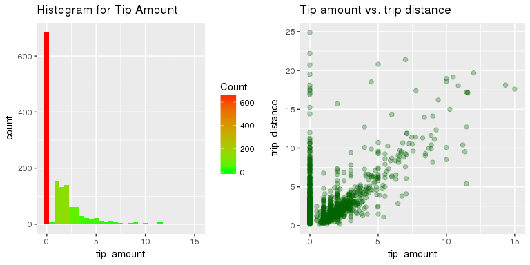

```r
###########################################
# SAMPLE SMALL PORTION OF DATA
###########################################
trip_fare_featSampled <- SparkR::sample(trip_fare_feat, withReplacement=FALSE,
                                fraction=0.0001, seed=123)

###########################################
# CONVERT SPARK DF TO LOCAL DATA.FRAME IN MEMORY OF R-SERVER EDGE NODE
###########################################
trip_fare_featSampledDF <- as.data.frame(trip_fare_featSampled);

###########################################
# Generate HISTOGRAM OF TIP AMOUNT
###########################################
hist <- ggplot(trip_fare_featSampledDF, aes(x=tip_amount)) +
  geom_histogram(binwidth = 0.5, aes(fill = ..count..)) +
  scale_fill_gradient("Count", low = "green", high = "red") +
  labs(title="Histogram for Tip Amount");

###########################################
# Generate Scatter Plot OF TRIP DISTANCE vs. TIP AMOUNT
###########################################
scatter <- ggplot(trip_fare_featSampledDF, aes(tip_amount, trip_distance)) +
  geom_point(col='darkgreen', alpha=0.3, pch=19, cex=2) +
  labs(title="Tip amount vs. trip distance");

###########################################
# Plot Histogram and Scatter Plot OF TIP AMOUNT Side by Side
###########################################
grid.arrange(hist, scatter, ncol=2)
```

## 2.4 Down-sample data for modeling

If a data-set is large, it may need to be down-sampled for modeling in reasonable amount of time. Here we used the **sample** function from SparkR to down-sample the joined trip-fare data. We then save the data in HDFS for use as input into the sparklyr modeling functions.

```r
###########################################
# SAMPLE DATA FOR MODELING
###########################################
trip_fare_featSampled <- sample(trip_fare_feat, withReplacement=FALSE,
                                fraction=0.1, seed=123)

###########################################
# REPARTITION DATA FOR SAVING
###########################################
trip_fare_featSampledRepartitioned <- repartition(trip_fare_featSampled, 10) # write.df below will produce this many files

###########################################
# SAVE DATAFRANE AS PARQUET file
###########################################
write.df(df=trip_fare_featSampledRepartitioned,
         path=file.path(fullDataDir, "NYCjoinedParquetSubset"), source="parquet", mode="overwrite")

###########################################
# UNPERSIST CACHED DATA FRAME
###########################################
SparkR::unpersist(trip_fare_feat)
```

```
## SparkDataFrame[payment_type:string, pickup_hour:int, fare_amount:double, tip_amount:double, passenger_count:int, trip_distance:double, trip_time_in_secs:int, TrafficTimeBins:string, tipped:int]
```

```r
###########################################
# STOP SPARKR CONTEXT
###########################################
sparkR.stop()
```

# 3 Summary

The examples shown here can be adopted to fit other data exploration and wrangling scenarios using SparkR.